# HW4

Computing descriptive statistics and creating visualizations

Pragyanta Dhal  
2022-05-11

### Load libraries

```r
library(readr)
library(dplyr)
library(ggplot2)
```

### Data Loading of cleaned data

```r
student_final <- read_csv("./student_final_data.csv")
str(student_final)
```

```
spec_tbl_df [1,000 × 12] (S3: spec_tbl_df/tbl_df/tbl/data.frame)
 $ ...1                    : num [1:1000] 1 2 3 4 5 6 7 8 9 10 ...
 $ gender                  : chr [1:1000] "female" "female" "female" "male" ...
 $ race_ethnicity_group    : chr [1:1000] "group B" "group C" "group B" "group A" ...
 $ parent_highest_education: chr [1:1000] "bachelor's degree" "some college" "master's degree" "associate's degree" ...
 $ lunch                   : chr [1:1000] "standard" "standard" "standard" "free/reduced" ...
 $ test_preparation_course : chr [1:1000] "none" "completed" "none" "none" ...
 $ math_marks              : num [1:1000] 72 69 90 47 76 71 88 40 64 38 ...
 $ reading_marks           : num [1:1000] 72 90 95 57 78 83 95 43 64 60 ...
 $ writing_marks           : num [1:1000] 74 88 93 44 75 78 92 39 67 50 ...
 $ total_marks             : num [1:1000] 218 247 278 148 229 232 275 122 195 148 ...
 $ mean_marks              : num [1:1000] 72.7 82.3 92.7 49.3 76.3 ...
 $ grade                   : chr [1:1000] "C" "B" "A" "F" ...
 - attr(*, "spec")=
  .. cols(
  ..   ...1 = col_double(),
  ..   gender = col_character(),
  ..   race_ethnicity_group = col_character(),
  ..   parent_highest_education = col_character(),
  ..   lunch = col_character(),
  ..   test_preparation_course = col_character(),
  ..   math_marks = col_double(),
  ..   reading_marks = col_double(),
  ..   writing_marks = col_double(),
  ..   total_marks = col_double(),
  ..   mean_marks = col_double(),
  ..   grade = col_character()
  .. )
 - attr(*, "problems")=<externalptr>
```

## Descriptive statistics

### Descriptive statistics of numerical columns

Mean of the numeric columns:

```r
student_final %>%
    summarise_if(is.numeric, mean)
```

```
# A tibble: 1 × 6
   ...1 math_marks reading_marks writing_marks total_marks mean_marks
  <dbl>      <dbl>         <dbl>         <dbl>       <dbl>      <dbl>
1  500.       66.1          69.2          68.1        203.       67.8
```

Median of the numeric columns:

```r
student_final %>%
    summarise_if(is.numeric, median)
```

```
# A tibble: 1 × 6
   ...1 math_marks reading_marks writing_marks total_marks mean_marks
  <dbl>      <dbl>         <dbl>         <dbl>       <dbl>      <dbl>
1  500.         66            70            69         205       68.3
```

Standard deviation of the numeric columns:

```r
student_final %>%
    summarise_if(is.numeric, sd)
```

```
# A tibble: 1 × 6
   ...1 math_marks reading_marks writing_marks total_marks mean_marks
  <dbl>      <dbl>         <dbl>         <dbl>       <dbl>      <dbl>
1  289.       15.2          14.6          15.2        42.8       14.3
```

### Descriptive statistics of categorical columns

Frequency of gender

```r
student_final %>%
     group_by(gender) %>%
     summarise(count = n())
```

```
# A tibble: 2 × 2
  gender count
  <chr>  <int>
1 female   518
2 male     482
```

Frequency of ethnicity group of students:

```r
student_final %>%
     group_by(race_ethnicity_group) %>%
     summarise(count = n())
```

```
# A tibble: 5 × 2
  race_ethnicity_group count
  <chr>                <int>
1 group A                 89
2 group B                190
3 group C                319
4 group D                262
5 group E                140
```

Frequency of the highest education obtained by parents:

```r
student_final %>%
     group_by(parent_highest_education) %>%
     summarise(count = n())
```

```
# A tibble: 6 × 2
  parent_highest_education count
  <chr>                    <int>
1 associate's degree         222
2 bachelor's degree          118
3 high school                196
4 master's degree             59
5 some college               226
6 some high school           179
```

Frequency of the type of lunch:

```r
student_final %>%
     group_by(lunch) %>%
     summarise(count = n())
```

```
# A tibble: 2 × 2
  lunch        count
  <chr>        <int>
1 free/reduced   355
2 standard       645
```

Frequency of the completion of course materials:

```r
student_final %>%
     group_by(test_preparation_course) %>%
     summarise(count = n())
```

```
# A tibble: 2 × 2
  test_preparation_course count
  <chr>                   <int>
1 completed                 358
2 none                      642
```

### Descriptive statistics of relevant grouping

Calculating mean, median and Standard deviation of the marks obtained in Maths, grouped by gender:

```r
student_final %>%
     group_by(gender) %>%
     summarise(gender_count = n(), mean_math_marks = mean(math_marks), median_math_marks = median(math_marks), sd_math_marks = sd(math_marks))
```

```
# A tibble: 2 × 5
  gender gender_count mean_math_marks median_math_marks sd_math_marks
  <chr>         <int>           <dbl>             <dbl>         <dbl>
1 female          518            63.6                65          15.5
2 male            482            68.7                69          14.4
```

Calculating mean, median and Standard deviation of the marks obtained in Maths, grouped by ethnic group:

```r
student_final %>%
     group_by(race_ethnicity_group) %>%
     summarise(race_ethnicity_group_count = n(), mean_math_marks = mean(math_marks), median_math_marks = median(math_marks), sd_math_marks = sd(math_marks))
```

```
# A tibble: 5 × 5
  race_ethnicity_gr… race_ethnicity_… mean_math_marks median_math_mar…
  <chr>                         <int>           <dbl>            <dbl>
1 group A                          89            61.6             61
2 group B                         190            63.5             63
3 group C                         319            64.5             65
4 group D                         262            67.4             69
5 group E                         140            73.8             74.5
# … with 1 more variable: sd_math_marks <dbl>
```

Calculating mean, median and Standard deviation of the marks obtained in Maths, grouped by gender and completion of test courses:

```r
student_final %>%
  group_by(gender, test_preparation_course) %>%
  summarise(count_gender= n(), mean_math_marks = mean(math_marks), median_math_marks = median(math_marks), sd_math_marks = sd(math_marks))
```

```
# A tibble: 4 × 6
# Groups:   gender [2]
  gender test_preparation_course count_gender mean_math_marks
  <chr>  <chr>                          <int>           <dbl>
1 female completed                        184            67.2
2 female none                             334            61.7
3 male   completed                        174            72.3
4 male   none                             308            66.7
# … with 2 more variables: median_math_marks <dbl>,
#   sd_math_marks <dbl>
```

# Visualizations

### Frequency of students across ethnic groups

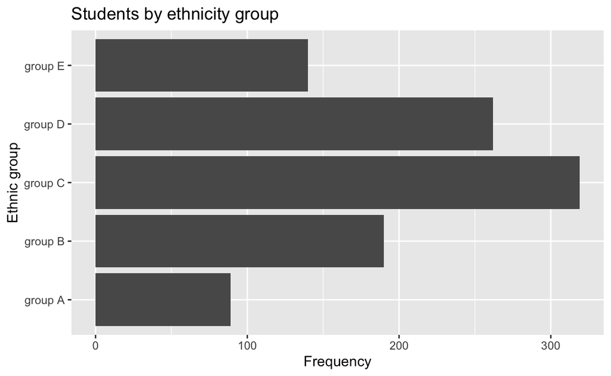

```r
ggplot(student_final, aes(x = race_ethnicity_group)) +
     geom_bar() +
     labs(x = "Ethnic group",
          y = "Frequency",
          title = "Students by ethnicity group") +
     coord_flip()
```

### Frequency of mean marks

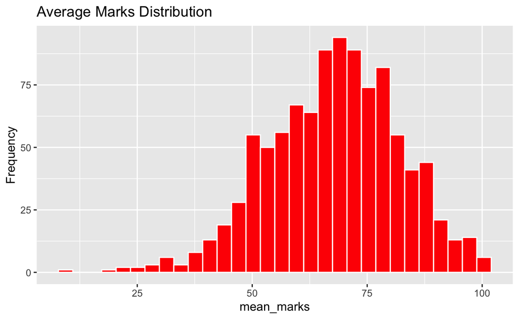

```r
ggplot(student_final, aes(x = mean_marks)) +
     geom_histogram(fill = "red", color = "white") +
     labs(title = "Average Marks Distribution",
          x = "mean_marks", y = "Frequency")
```

### Gender vs Mean Marks

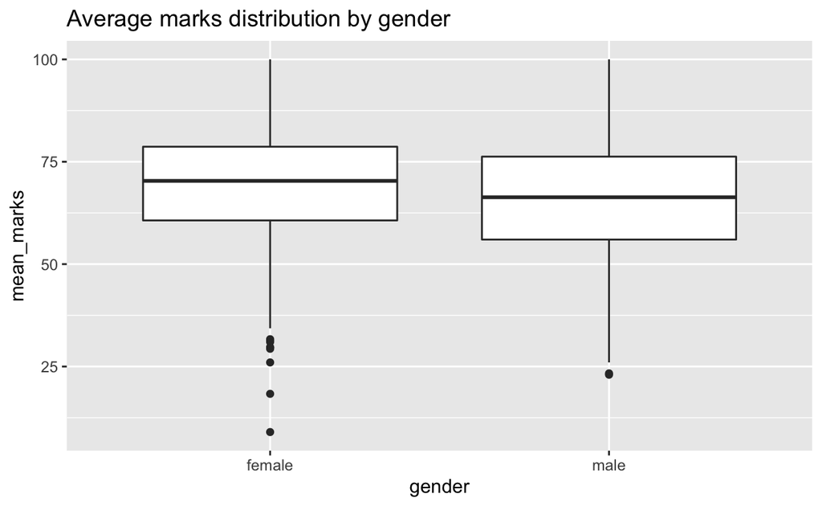

```r
ggplot(student_final,
        aes(x = gender,
            y = mean_marks)) +
     geom_boxplot() +
     labs(title = "Average marks distribution by gender")
```

This is a bivariate plot of a categorical variable(gender) and a continuous variable (mean_marks). It is a box plot that shows summaries like median and quartile ranges.

### Reading Marks vs Writing Marks

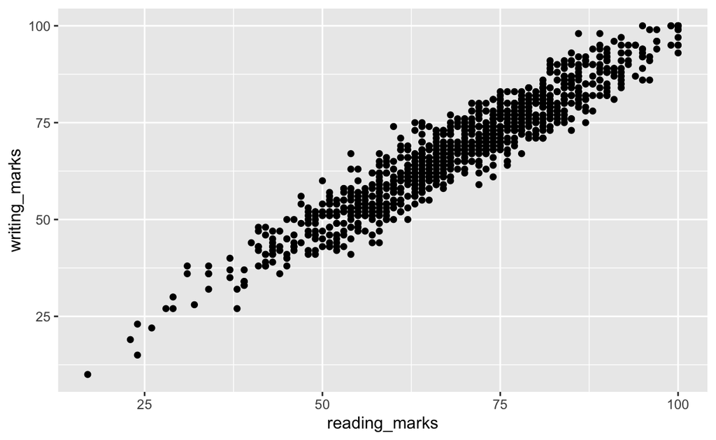

```r
ggplot(student_final,
        aes(x = reading_marks,
            y = writing_marks)) +
     geom_point()
```

This is a bivariate plot of two continuous variables namely reading_marks and writing_marks. It is observed that students who perform well in reading performed well in writing as well.

## Limitations

Although the univariate analysis have the benefit of not sacrificing any specific information, the downside is when there are a high number of data points it may be difficult to obtain an overall perspective of a variable’s qualities. They may not allow for a straightforward comparison of variables, one to another. On the other hand, the bivariate plots can be made aesthetically pleasing for the reader. Both the plots warrant further improvements.